# Confronto Italia - Irlanda - Danimarca

Enrico Guerriero

21/10/2022

### Consegna e premesse

La consegna del progetto è confrontare serie storiche di Italia, Irlanda e Danimarca rispetto a 3 parametri: * Prezzi delle case * PIL (GDP) * Disoccupazione

## Confronto tra i prezzi delle case

La prima richiesta è effettuare il confronto tra i prezzi delle case. Come prima cosa scarico il database sui numeri indici dei prezzi delle case dal sito di OECD e lo carico su R.

```r
HousePriceDataframe <- read.csv("HousePriceDatabase.csv")
```

Adesso è sufficiente salvare nelle variabili soltanto i valori delle serie storiche.

```r
HPItaly <- HousePriceDataframe[HousePriceDataframe$ï..LOCATION == "ITA", ]$Value
HPIreland <- HousePriceDataframe[HousePriceDataframe$ï..LOCATION == "IRL", ]$Value
HPDenmark <- HousePriceDataframe[HousePriceDataframe$ï..LOCATION == "DNK", ]$Value
```

Una volta salvati i valori di interesse, è possibile stampare un primo grafico per farsi un’idea di come si sono disposti i dati.

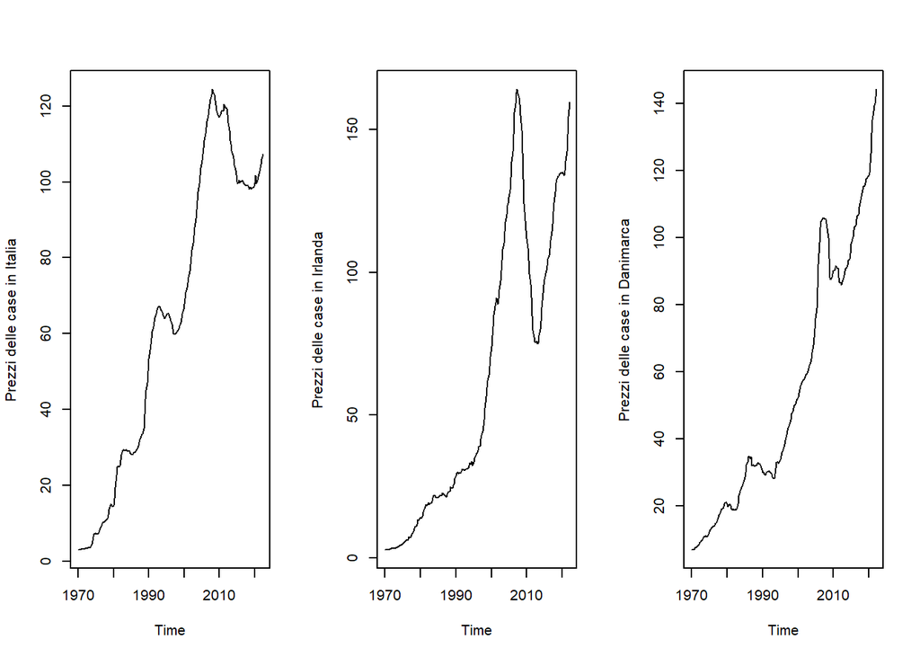

```r
par(mfrow=c(1,3))
plot(ts(HPItaly, start=c(1970,1), frequency = 4), ylab = "Prezzi delle case in Italia")
plot(ts(HPIreland, start=c(1970,1), frequency = 4), ylab = "Prezzi delle case in Irlanda")
plot(ts(HPDenmark, start=c(1970,1), frequency = 4), ylab = "Prezzi delle case in Danimarca")
```

Per avere un confronto migliore, stampo su un unico grafico tutti i dati.

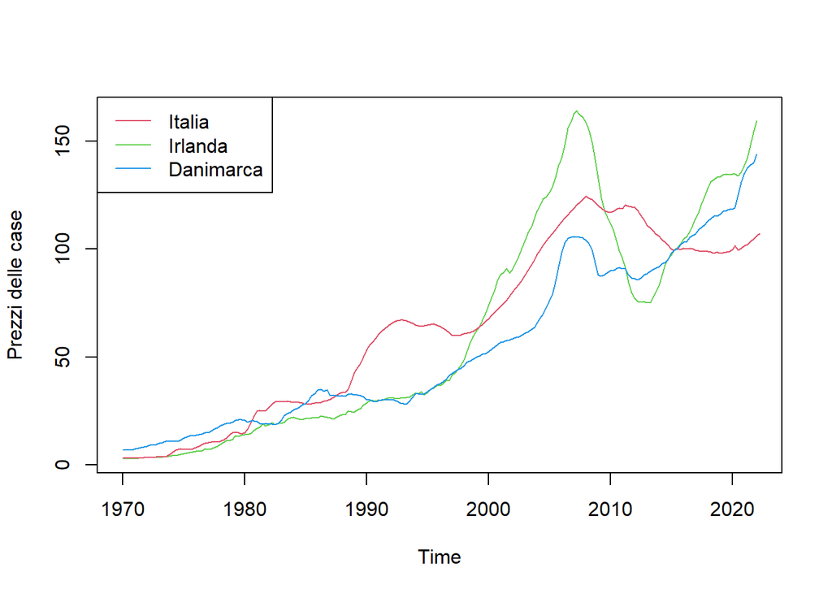

```r
plot(ts(HPIreland, start=c(1970,1), frequency = 4), type = "l", col=3, ylab = "Prezzi delle case")
lines(ts(HPItaly, start=c(1970,1), frequency = 4), type = "l", col=2)
lines(ts(HPDenmark, start=c(1970,1), frequency = 4), type = "l", col=4)
legend("topleft", c("Italia", "Irlanda", "Danimarca"), lty = 1, col = 2:4)
```

Ora considero una serie storica alla volta, partendo dall’Italia, e costruisco un modello di regressione lineare.

```r
#variabile di appoggio per effettuare la regressione
ttrend <- 1:length(HPItaly)
polymod1 <- lm(HPItaly ~ ttrend)
summary(polymod1)
```

```
##
## Call:
## lm(formula = HPItaly ~ ttrend)
##
## Residuals:
##     Min      1Q  Median      3Q     Max
## -24.648  -7.506  -2.294   7.566  31.372
##
## Coefficients:
##             Estimate Std. Error t value Pr(>|t|)
## (Intercept) -2.28326    1.81025  -1.261    0.209
## ttrend       0.62318    0.01488  41.887   <2e-16 ***
## ---
## Signif. codes:  0 '***' 0.001 '**' 0.01 '*' 0.05 '.' 0.1 ' ' 1
##
## Residual standard error: 13.07 on 208 degrees of freedom
## Multiple R-squared:  0.894,  Adjusted R-squared:  0.8935
## F-statistic:  1755 on 1 and 208 DF,  p-value: < 2.2e-16
```

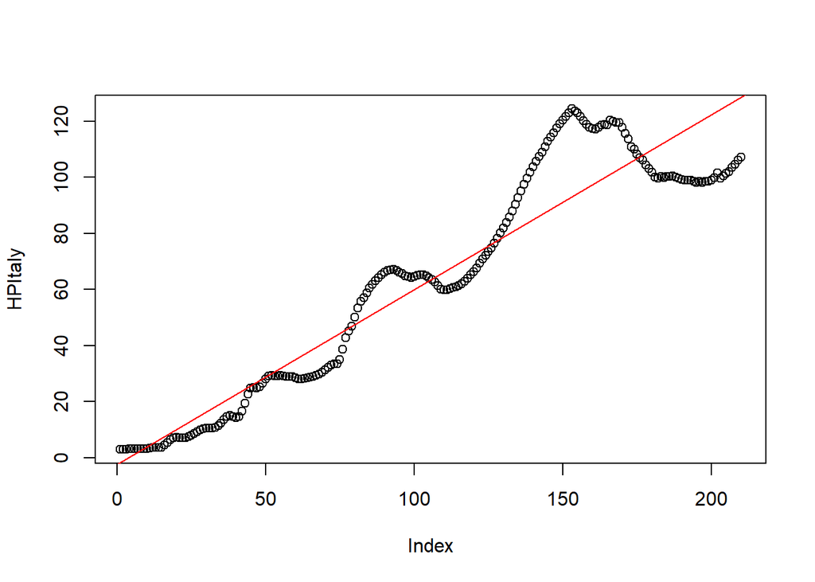

```r
plot(HPItaly)
abline(polymod1, col = "red")
```

Si osserva che il trend lineare potrebbe non essere il migliore per questo modello. Provo a confrontare l’ R^2 di vari trend polinomiali al fine di trovare il trend con l’R^2 più alto

```r
#provo a creare diversi trend polinomiali per confrontare gli R^2
#intanto creo la variabile di appoggio e il primo R^2
i <- 1
r.squared.succ <- summary(polymod1)$adj.r.squared
#do il valore 0 a r.squared solo per far partire il ciclo
r.squared <- 0
#assegno i valori per il primo ciclo
polymodnext <- polymod1
mytrend <- ttrend
#creo un ciclo while
while (r.squared.succ > r.squared) {
  r.squared <- r.squared.succ
  i <- i+1
  mytrend <- matrix(c(mytrend, ttrend^i), ncol=i)
  polymod <- polymodnext
  polymodnext <- lm(HPItaly ~ mytrend)
  r.squared.succ <- summary(polymodnext)$adj.r.squared
}
summary(polymod)
```

```
##
## Call:
## lm(formula = HPItaly ~ mytrend)
##
## Residuals:
##     Min      1Q  Median      3Q     Max
## -8.6169 -1.9786  0.4809  2.1117  6.3019
##
## Coefficients:
##               Estimate Std. Error t value Pr(>|t|)
## (Intercept) -2.902e+00  3.564e+00  -0.814 0.416573
## mytrend1     3.313e+00  1.558e+00   2.126 0.034769 *
## mytrend2    -4.738e-01  2.273e-01  -2.084 0.038426 *
## mytrend3     2.776e-02  1.583e-02   1.753 0.081107 .
## mytrend4    -7.117e-04  6.241e-04  -1.140 0.255517
## mytrend5     5.858e-06  1.527e-05   0.384 0.701674
## mytrend6     1.075e-07  2.444e-07   0.440 0.660486
## mytrend7    -3.356e-09  2.630e-09  -1.276 0.203487
## mytrend8     3.997e-11  1.916e-11   2.086 0.038253 *
## mytrend9    -2.650e-13  9.314e-14  -2.845 0.004904 **
## mytrend10    1.024e-15  2.894e-16   3.539 0.000501 ***
## mytrend11   -2.162e-18  5.197e-19  -4.160 4.74e-05 ***
## mytrend12    1.931e-21  4.102e-22   4.708 4.71e-06 ***
## ---
## Signif. codes:  0 '***' 0.001 '**' 0.01 '*' 0.05 '.' 0.1 ' ' 1
##
## Residual standard error: 3.21 on 197 degrees of freedom
## Multiple R-squared:  0.9939, Adjusted R-squared:  0.9936
## F-statistic:  2695 on 12 and 197 DF,  p-value: < 2.2e-16
```

Dal ciclo while emerge che il grado ideale del polinomio di interpolazione migliore è 12. Provo quindi a stampare il polinomio di grado 12.

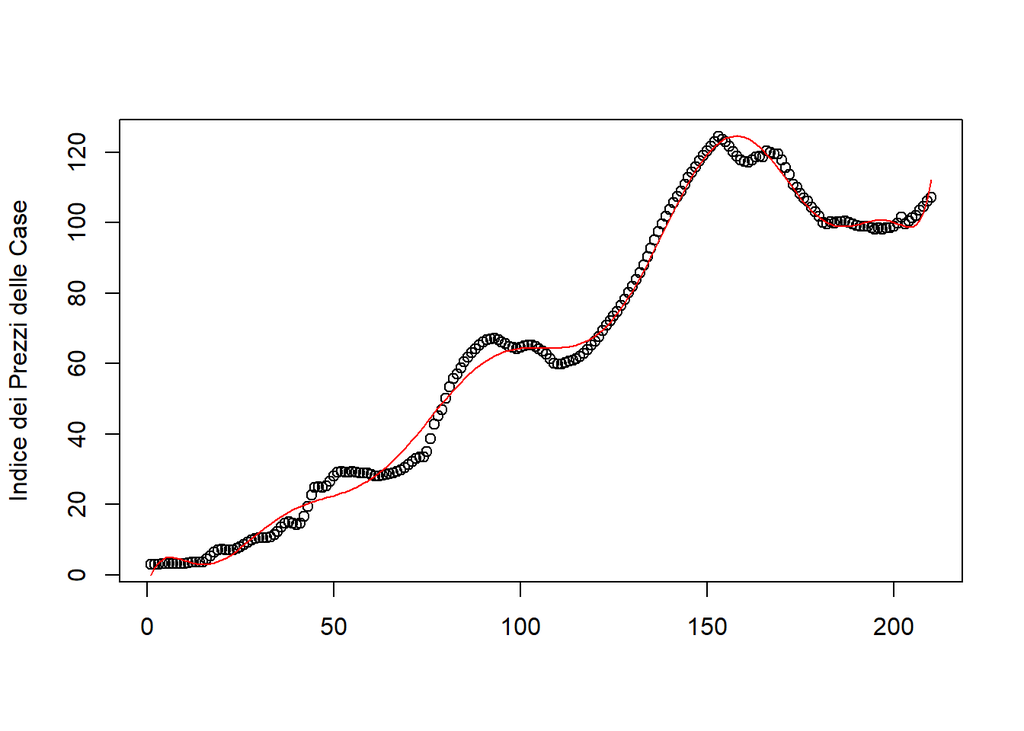

```r
plot(HPItaly, ylab = "Indice dei Prezzi delle Case", xlab = "")
lines(fitted(polymod), col = "red")
```

Il polinomio sembra aderire bene ai dati, ma ora verifichiamo analizzando i residui.

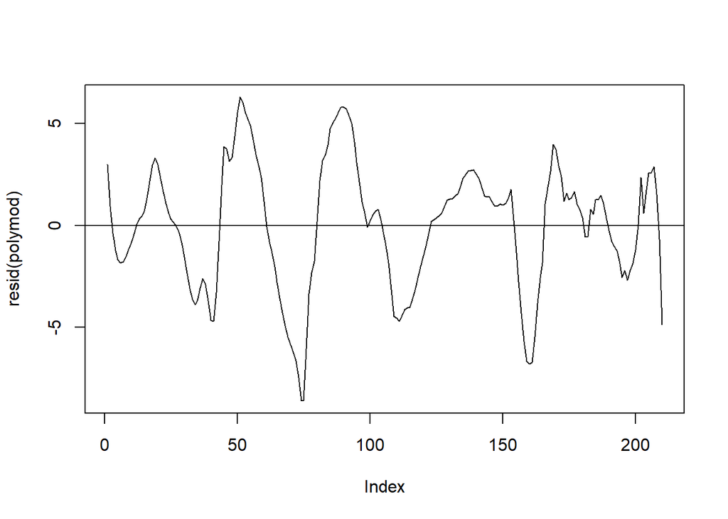

```r
plot(resid(polymod), type = "l")
abline(0,0)
```

I residui sembrano essere distribuiti in modo casuale intorno allo 0, quindi la funzione potrebbe essere adeguata. Tuttavia, ad un’analisi più attenta, tenderei ad escludere questo trend, poiché 12 gradi di un polinomio vogliono dire 12 punti di massimo e minimo relativi, pertanto detrendizzando i dati si corre un rischio troppo elevato di coinvolgere anche una componente ciclica caratteristica del mercato immobiliare. Un ulteriore problema che potrebbe emergere è il non poter ricondurre picchi (in positivo o in negativo) ad eventi precisi che possano aver alterato il mercato, lasciando ingiustificata tutta questa variabilità.

Alla luce di questi ragionamenti, riprendo in considerazione il trend lineare e ne analizzo i residui.

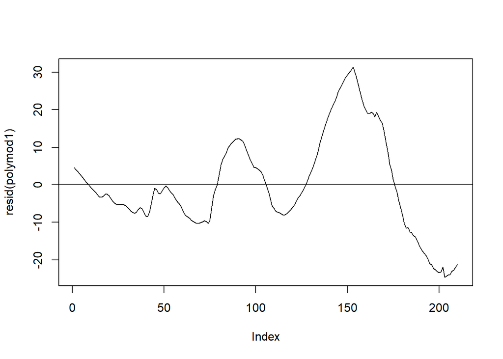

```r
plot(resid(polymod1), type = "l")
abline(0,0)
```

Anche in questo caso, però, osservando la distribuzione dei residui (e considerando che l’R^2 è continuato a salire fino al grado 12) si può osservare come un polinomio di grado 1 non approssimi sufficientemente accuratamente il fenomeno. Provo pertanto con un polinomio di grado 3

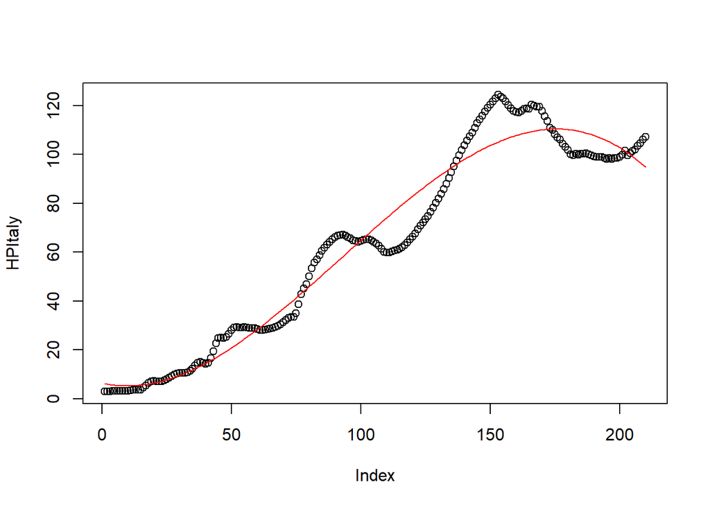

```r
polymod3 <- lm(HPItaly ~ ttrend + I(ttrend^2) + I(ttrend^3))
plot(HPItaly)
lines(fitted(polymod3), col = "red")
```

Il modello sembra più efficiente. Provo a vedere la distribuzione detrendizzata.

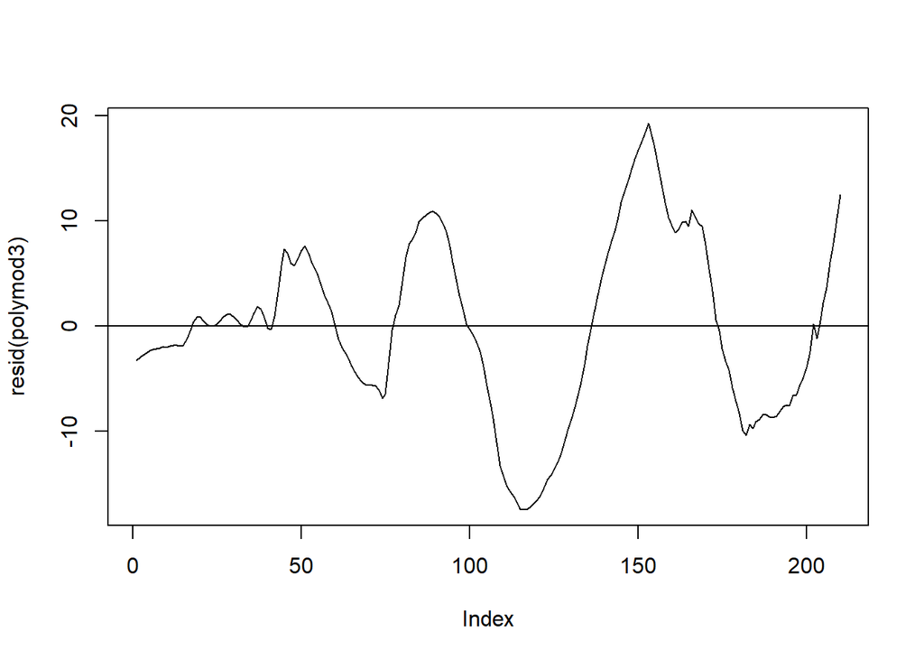

```r
plot(resid(polymod3), type = "l")
abline(0,0)
```

Dal grafico sembra esserci ancora una componente ciclica, ma forse non è messa in evidenza adeguatamente dal trend.

Provo quindi a verificare i trend non esprimibili tramite polinomio. Il trend che sembra più plausibile è quello logistico.

```r
logismod <- nls(HPItaly ~ I(a/(1+b*exp(-k*ttrend))),
                start=list(a=100, b=12, k=0.3), trace=TRUE)
```

```
## 509659.2    (9.99e-01): par = (100 12 0.3)
## 395607.2    (9.30e-01): par = (92.46418 4.641838 0.1712606)
## 277277.9    (1.29e+00): par = (87.7514 2.805483 0.07683384)
## 139960.3    (2.40e+00): par = (87.21243 2.37066 0.0308707)
## 101876.1    (2.09e+00): par = (100.0044 3.990202 0.01583393)
## 74654.81    (1.66e+00): par = (82.80256 9.378132 0.03792816)
## 40603.51    (1.08e+00): par = (96.65162 11.86994 0.03031387)
## 20880.99    (3.38e-01): par = (112.1451 21.2825 0.03573955)
## 18737.38    (3.65e-02): par = (112.4225 24.47186 0.03517256)
## 18716.37    (9.69e-03): par = (112.1147 26.16993 0.03592412)
## 18715.02    (2.66e-03): par = (112.2868 25.92854 0.03573716)
## 18714.92    (8.30e-04): par = (112.2363 26.04762 0.03580351)
## 18714.92    (2.60e-04): par = (112.253 26.01265 0.03578314)
## 18714.91    (8.13e-05): par = (112.2478 26.02384 0.03578956)
## 18714.91    (2.54e-05): par = (112.2494 26.02036 0.03578755)
## 18714.91    (7.97e-06): par = (112.2489 26.02146 0.03578818)
```

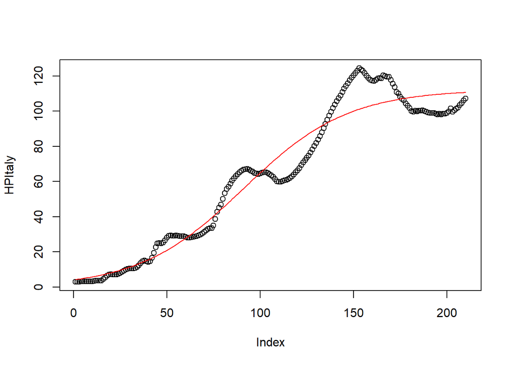

```r
plot(HPItaly)
lines(fitted(logismod), col = "red")
```

Il modello sembra interessante, ora provo a stampare i residui:

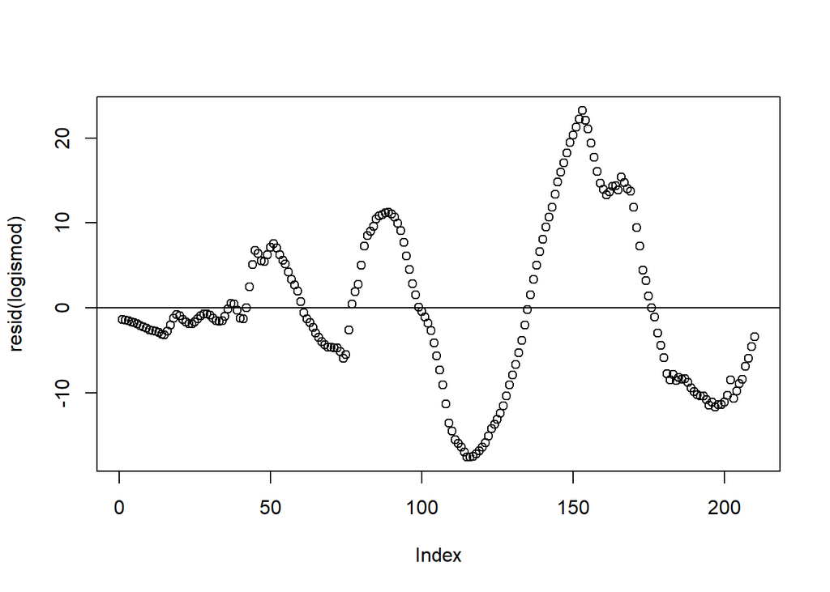

```r
plot(resid(logismod))
abline(0,0)
```